# MA22019 2025 - Homework 8

Semi-variogram and principal component analysis

### **Overview**

Your answer to the Homework Question can be submitted on Moodle to your tutor for feedback. The submission deadline is 17:00 on Thursday 3 April 2025. You should submit a single PDF or Word file that provides your R code, any created R output and all your comments.

You may want to load the following packages before starting the exercise:

```r
library( dplyr )
library( lubridate )
library( ggplot2 )
library( tidyr )
library( sf )
library( ggspatial )
library( prettymapr )
library( sp )
library( gstat )
```

When working on a University PC, you will have to first install some of these packages.

### **Homework Question - Spatial dependence in temperatures across Brazil**

Let’s again consider the temperature data from Brazil considered in Problem Sheet 6. The data are provided in the file “Brazil Temperature.csv”. In the following we want to explore the spatial dependence in the data.

1. Estimate the semi-variogram for the data. What do you conclude about the spatial dependence in the observed temperatures?
2. Discuss whether it is reasonable to assume that the spatial random process has a constant mean and that the value of the semi-variogram is fully specified by the distance between spatial sites.
3. **Bonus:** One may argue that the constant mean assumption may not hold for the spatial process $\{X(\mathbf{s}) : \mathbf{s}\in\mathcal{S}\}$. The variogram() function allows us to define a model of the form
   $$\begin{equation}
   X(\mathbf{s}) = \beta_0 + \beta_1\mathrm{Longitude}(\mathbf{s}) +
   \beta_2\mathrm{Latitude}(\mathbf{s}) + Z(\mathbf{s}),
   \end{equation}$$
   where $\{Z(\mathbf{s}) : \mathbf{s}\in\mathcal{S}\}$ is termed the residual random process. The semi-variogram estimated by the variogram() function then corresponds to that for the residual random process. In R, we derive and visualize this estimate using

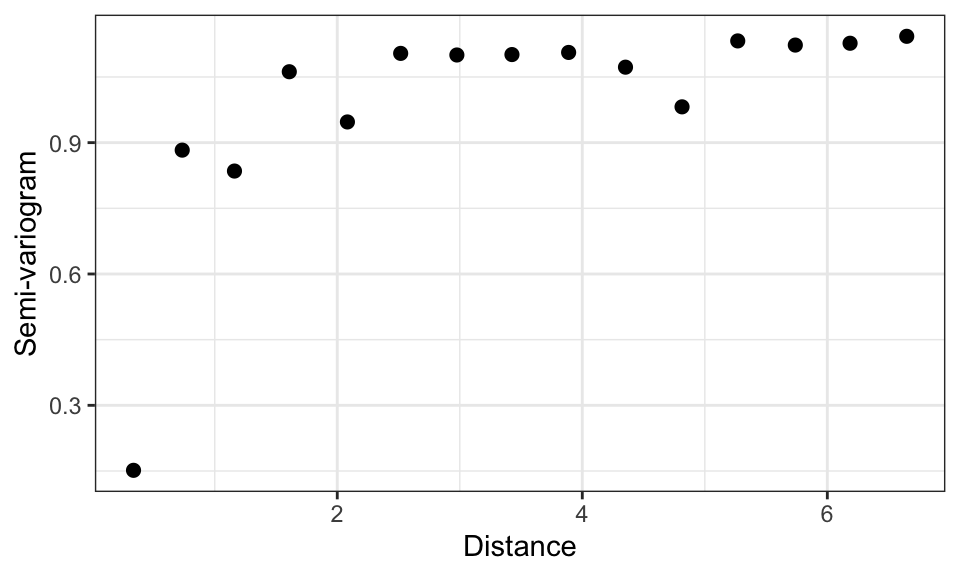

```r
Brazil <- read.csv( "Brazil Temperature.csv" )
coordinates( Brazil ) <- ~Lon+Lat
gamma_hat <- variogram( MeanTemp ~Lon+Lat, data = Brazil )
ggplot( gamma_hat, aes( x=dist, y=gamma/2 ) ) + geom_point( size=2 ) +
  theme_bw() + labs( x="Distance", y="Semi-variogram" )
```

Describe the similarities and differences between this estimate and yours in part a). Discuss whether the conclusions we draw regarding spatial dependence in the residual process are the same as for the process in part a).

**Remark:** You may learn more about the type of models in Equation (1) in Statistical Modelling & Data Analytics 3B.